# Bicycle Rentals

## Library Includes

```r
library(tidyverse)      # General utility packages
library(corrplot)       # Visual correlation plotting
library(cowplot)        # Plotting ggplot's side by side
library(olsrr)          # Useful toolset specific to linear regression models
library(car)            # Useful toolset specific to linear regression models
library(lubridate)      # Used for date manipulation
```

## Preparing Data

```r
bikes <- read_csv("data/bikes.csv")
```

```r
options(width = 100)
glimpse(bikes)
```

```
Rows: 731
Columns: 10
$ date        <date> 2011-01-01, 2011-01-02, 2011-01-03, 2011-01-04, 2011-01-05, 2011-01-06, 2011…
$ season      <dbl> 1, 1, 1, 1, 1, 1, 1, 1, 1, 1, 1, 1, 1, 1, 1, 1, 1, 1, 1, 1, 1, 1, 1, 1, 1, 1,…
$ holiday     <dbl> 0, 0, 0, 0, 0, 0, 0, 0, 0, 0, 0, 0, 0, 0, 0, 0, 1, 0, 0, 0, 0, 0, 0, 0, 0, 0,…
$ weekday     <dbl> 6, 0, 1, 2, 3, 4, 5, 6, 0, 1, 2, 3, 4, 5, 6, 0, 1, 2, 3, 4, 5, 6, 0, 1, 2, 3,…
$ weather     <dbl> 2, 2, 1, 1, 1, 1, 2, 2, 1, 1, 2, 1, 1, 1, 2, 1, 2, 2, 2, 2, 1, 1, 1, 1, 2, 3,…
$ temperature <dbl> 46.71653, 48.35024, 34.21239, 34.52000, 36.80056, 34.88784, 34.22576, 31.5590…
$ realfeel    <dbl> 46.39865, 45.22419, 25.70131, 28.40009, 30.43728, 30.90523, 28.01007, 22.4757…
$ humidity    <dbl> 0.805833, 0.696087, 0.437273, 0.590435, 0.436957, 0.518261, 0.498696, 0.53583…
$ windspeed   <dbl> 6.679665, 10.347140, 10.337565, 6.673420, 7.780994, 3.728766, 7.024377, 11.10…
$ rentals     <dbl> 985, 801, 1349, 1562, 1600, 1606, 1510, 959, 822, 1321, 1263, 1162, 1406, 142…
```

Examining feature correlations.

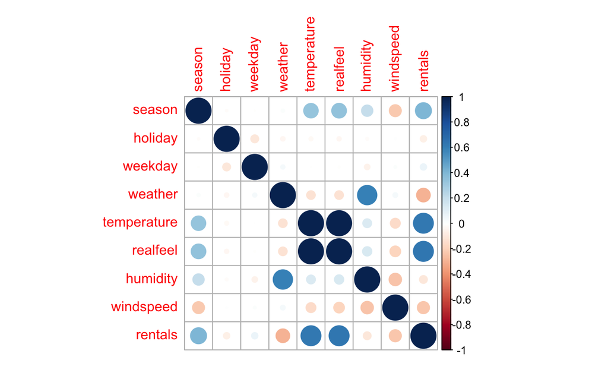

```r
bike_correlations <- bikes %>%
  select(-date) %>%
  cor()

corrplot(bike_correlations, mar=c(1,0,1,4))
```

Taking a visual look at the higher correlations to rentals.

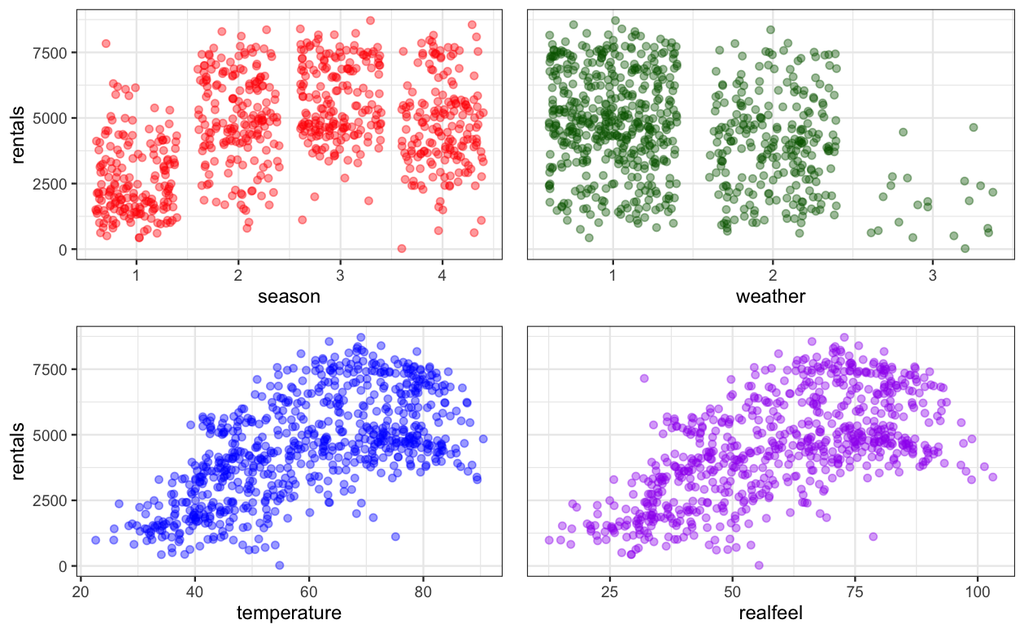

```r
p1 <- ggplot(bikes, aes(x=season, y=rentals)) +
  geom_jitter(colour="red", alpha = 0.4)

p2 <- ggplot(bikes, aes(x=weather, y=rentals)) +
  geom_jitter(colour="darkgreen", alpha = 0.4) +
  theme(axis.title.y=element_blank(), axis.text.y=element_blank(), axis.ticks.y=element_blank())

p3 <- ggplot(bikes, aes(x=temperature, y=rentals)) +
  geom_point(colour="blue", alpha = 0.4)

p4 <- ggplot(bikes, aes(x=realfeel, y=rentals)) +
  geom_point(colour="purple", alpha = 0.4) +
  theme(axis.title.y=element_blank(), axis.text.y=element_blank(), axis.ticks.y=element_blank())

plot_grid(p1, p2, p3, p4, nrow = 2)
```

Taking a look at distribution curves for all continuous feature data.

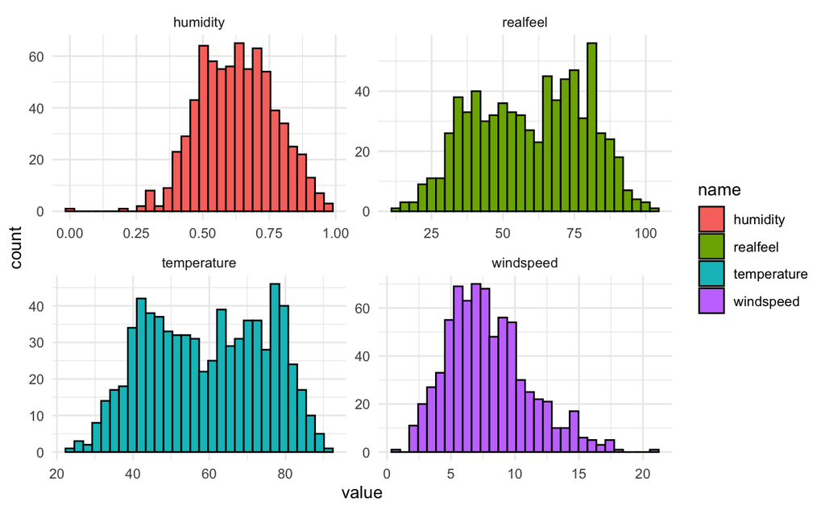

```r
bikes %>%
  select(-rentals, -holiday, -season, -weather, -weekday) %>%
  keep(is.numeric) %>%
  pivot_longer(cols = everything()) %>%
  ggplot(aes(x=value,fill=name)) +
    geom_histogram(color = "black", bins = 30) +
    facet_wrap(~ name, scales = "free") +
    theme_minimal()
```

```r
NA
```

## Model Preparation

Building a simple linear regression model. The coefficient estimates below represent the actual (m and b) coefficients for y = mx + b, specifically y = 78.495x - 166.877. Residuals represent the observed value minus the predicted value (error in prediction). Also take note that the temperature coefficient has *** next to it, signifying its predictive power as a feature, which in this case is highly significant.

```r
bikes_mod1 <- lm(data = bikes, rentals ~ temperature)
summary(bikes_mod1)
```

```
Call:
lm(formula = rentals ~ temperature, data = bikes)

Residuals:
    Min      1Q  Median      3Q     Max
-4615.3 -1134.9  -104.4  1044.3  3737.8

Coefficients:
            Estimate Std. Error t value Pr(>|t|)
(Intercept) -166.877    221.816  -0.752    0.452
temperature   78.495      3.607  21.759   <2e-16 ***
---
Signif. codes:  0 ‘***’ 0.001 ‘**’ 0.01 ‘*’ 0.05 ‘.’ 0.1 ‘ ’ 1

Residual standard error: 1509 on 729 degrees of freedom
Multiple R-squared:  0.3937,    Adjusted R-squared:  0.3929
F-statistic: 473.5 on 1 and 729 DF,  p-value: < 2.2e-16
```

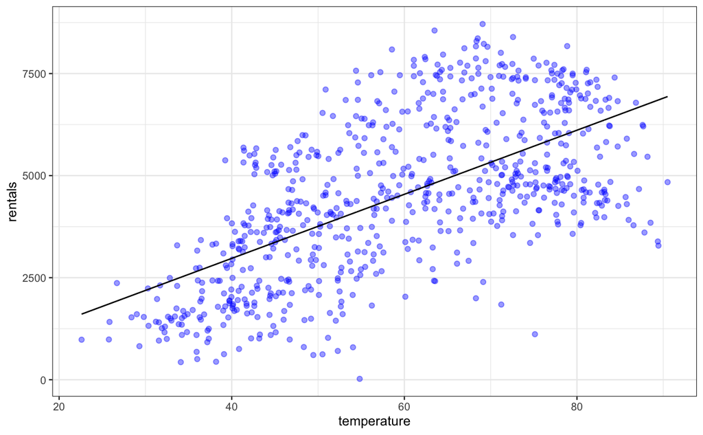

```r
bikes$pred1 <- predict(bikes_mod1)

ggplot(bikes, aes(x=temperature, y=rentals)) +
  geom_point(colour="blue", alpha = 0.4) +
  geom_line(aes(x=temperature, y=pred1))
```

Let’s give multiple linear regression a try now to improve upon our simple linear regression model. What’s interesting with the results of the model is the asterisks appearing after the coefficients appear to all be *** which signals that they are all significant predictors. However, when looking back at the original correlation matrix, my natural instincts would have led me to believe that humidity wouldn’t be good and windspeed would only be moderately good (based on the correlation to rentals). Also of note is our Adjusted R-squared is 45.8%, so our model has improved it’s ability to describe the variability of the dataset.

```r
bikes_mod2 <- lm(data = bikes, rentals ~ humidity + windspeed + temperature)
summary(bikes_mod2)
```

```
Call:
lm(formula = rentals ~ humidity + windspeed + temperature, data = bikes)

Residuals:
    Min      1Q  Median      3Q     Max
-4780.5 -1082.6   -62.2  1056.5  3653.5

Coefficients:
             Estimate Std. Error t value Pr(>|t|)
(Intercept)  2706.002    367.483   7.364 4.86e-13 ***
humidity    -3100.123    383.992  -8.073 2.83e-15 ***
windspeed    -115.463     17.028  -6.781 2.48e-11 ***
temperature    78.316      3.464  22.606  < 2e-16 ***
---
Signif. codes:  0 ‘***’ 0.001 ‘**’ 0.01 ‘*’ 0.05 ‘.’ 0.1 ‘ ’ 1

Residual standard error: 1425 on 727 degrees of freedom
Multiple R-squared:  0.4609,    Adjusted R-squared:  0.4587
F-statistic: 207.2 on 3 and 727 DF,  p-value: < 2.2e-16
```

Let’s take a look at how the new model predicts for all 3 contributing features. Visually we are examining a given feature independently, but realize that the prediction y values are as a result of “all” contributing model features for the given observation.

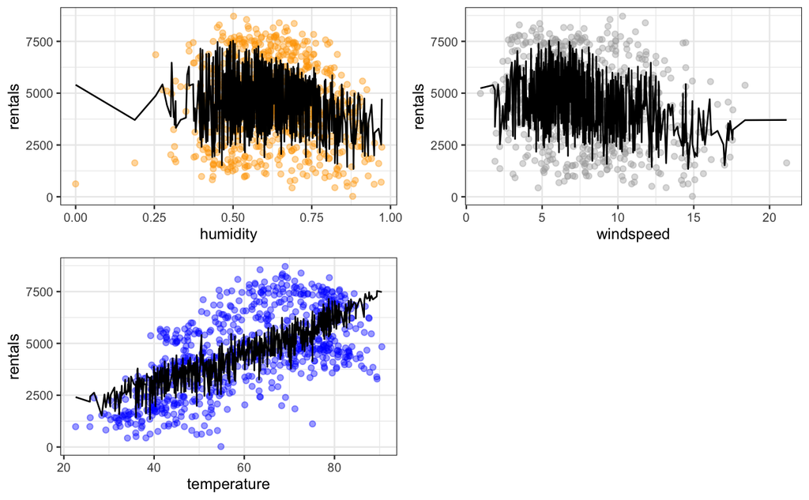

```r
bikes$pred2 <- predict(bikes_mod2)

p1 <- ggplot(bikes, aes(x=humidity, y=rentals)) +
  geom_point(colour="orange", alpha = 0.4) +
  geom_line(aes(x=humidity, y=pred2))

p2 <- ggplot(bikes, aes(x=windspeed, y=rentals)) +
  geom_point(colour="darkgrey", alpha = 0.4) +
  geom_line(aes(x=windspeed, y=pred2))

p3 <- ggplot(bikes, aes(x=temperature, y=rentals)) +
  geom_point(colour="blue", alpha = 0.4) +
  geom_line(aes(x=temperature, y=pred2))

plot_grid(p1, p2, p3, ncol = 2)
```

Here’s a concrete query to compare different days all hovering around the same temperature. We can see that the pred2 value indicating rentals varies considerably based on whether it’s low/high humidity and low/high windspeed for the day.

```r
bikes %>%
  filter(round(temperature) == 70) %>%
  select(temperature, humidity, windspeed, pred2)
```

| temperature | humidity | windspeed | pred2 |
| --- | --- | --- | --- |
| 70.05200 | 0.835417 | 12.997466 | 4101.575 |
| 69.84050 | 0.700833 | 13.359996 | 4460.379 |
| 69.77003 | 0.697083 | 14.265864 | 4361.892 |
| 70.05200 | 0.354167 | 10.537897 | 5877.498 |
| 69.77003 | 0.699167 | 7.197440 | 5171.571 |
| 70.19303 | 0.756667 | 6.369341 | 5122.056 |
| 70.12247 | 0.530417 | 10.589771 | 5330.631 |
| 69.62900 | 0.765833 | 4.919512 | 5216.869 |
| 70.19303 | 0.774583 | 4.246449 | 5311.629 |
| 70.33397 | 0.872500 | 14.887011 | 3790.524 |

[output cut: 2 more lines]

Here’s a clean example showing how to use our model, along with never-before-seen feature input data, to produce predictions (rentals). We can see that the model makes logical choices, when the humidity or wind is high, rentals seem to go down.

```r
freshInput <- tibble(temperature = 65, humidity = c(0.0, 0.4, 0.9, 0.4, 0.9), windspeed = c(0,5,5,15,15))
freshInput$pred <- predict(bikes_mod2, freshInput)
freshInput
```

| temperature | humidity | windspeed | pred |
| --- | --- | --- | --- |
| 65 | 0.0 | 0 | 7796.541 |
| 65 | 0.4 | 5 | 5979.178 |
| 65 | 0.9 | 5 | 4429.117 |
| 65 | 0.4 | 15 | 4824.551 |
| 65 | 0.9 | 15 | 3274.489 |

## Model Evaluation

#### Residual Diagnostics

Linear regression models make assumptions that are true, and if it turns out that some of these aren’t true, the accuracy of the model becomes suspect:

1. Have a mean of zero (or very close to it).
2. Are normally distributed.
3. Have equal variance across the values of the independent variable (homoscedasticity).
4. Are not correlated (that is, the residuals are not correlated).

Assumption #1 validation. As we can see below, this is very close to zero.

```r
mean(bikes_mod2$residuals)
```

```
[1] -2.92411e-13
```

Assumption #2 validation. As we can see below, the residual errors are indeed normally distributed.

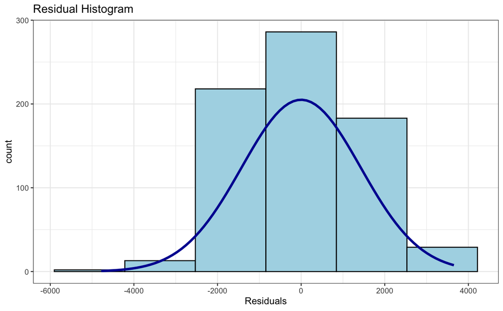

```r
ols_plot_resid_hist(bikes_mod2)
```

Assumption #3 validation. Since this is a well balanced plot, without a funnel shape leading to the right or left, this passes this check.

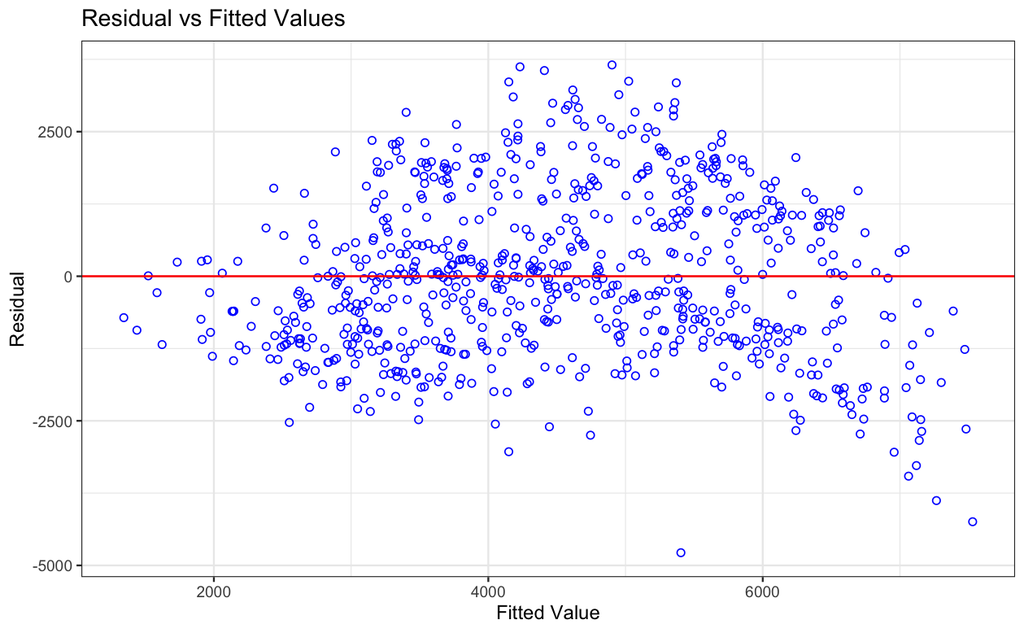

```r
ols_plot_resid_fit(bikes_mod2)
```

Assumption #4 validation. The DW statistic of 0.404 and p-value of 0 signal there is strong evidence suggesting the model’s residuals are positively correlated. To remediate this, we would need to identify which additional predictors, from our dataset, we need to include in our model. If that is unsuccessful in reducing residual autocorrelation, then we need to also look into transforming some of our predictor variables.

```r
durbinWatsonTest(bikes_mod2)
```

```
 lag Autocorrelation D-W Statistic p-value
   1       0.7963326     0.4042771       0
 Alternative hypothesis: rho != 0
```

#### Influential Point Analysis

Extreme values for predictor variables can create problems with the accuracy of linear regression models and with how well they can be generalized. If we have a model that can be heavily influenced or invalidated by a change in the value of a few observations, then we have a rather brittle model.

With simple linear regression, influential points are easy to identify by simply identifying the outlier values in a single predictor variable. However, with multiple linear regression, it is possible to have an observation with a variable whose value is not considered an outlier, when compared to other values for that variable, but is extreme when compared with the full set of predictors. To quantify these influential points when we’re dealing with multiple predictors, we use a statistical test known as Cook’s distance.

As can be seen below, there are several influential points, starting with a significant one (69).

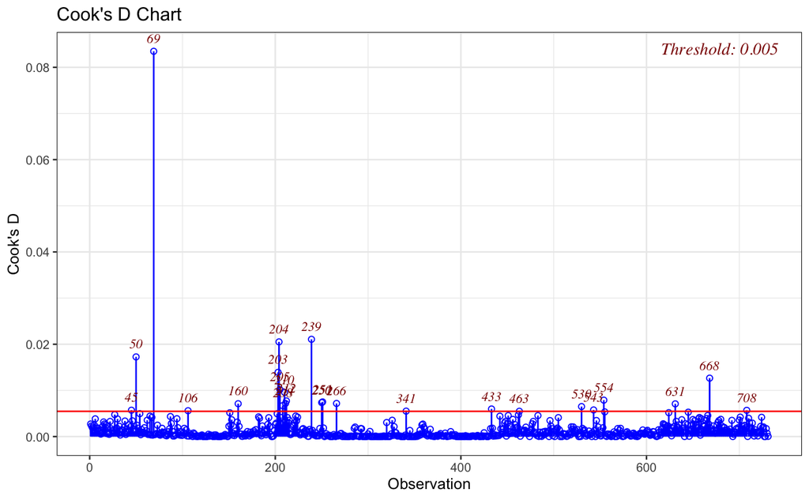

```r
ols_plot_cooksd_chart(bikes_mod2)
```

Here we’re tapping into the underlying data from above, and viewing the biggest influential outliers toward the top. In total there appear to be 25 outliers based on exceeding Cook’s distance threshold.

```r
cooksObj <- ols_plot_cooksd_chart(bikes_mod2, print_plot = FALSE)
cooksObj$outliers %>% arrange(desc(cooks_distance))
```

|  | observation | cooks_distance |
| --- | --- | --- |
| 69 | 69 | 0.083466470 |
| 239 | 239 | 0.021074076 |
| 204 | 204 | 0.020516659 |
| 50 | 50 | 0.017264207 |
| 203 | 203 | 0.013923865 |
| 668 | 668 | 0.012660294 |
| 205 | 205 | 0.010164468 |
| 210 | 210 | 0.009595062 |
| 554 | 554 | 0.007894590 |
| 212 | 212 | 0.007714449 |

[output cut: 15 more lines]

Let’s compare observation values between observation 69 and the rest. We see that humidity is clearly an outlier for 69, namely, 0, the lowest in the entire set of data. Likewise, windspeed is higher than the 3rd quartile. Through all of this, the temperature is not extreme.

```r
bikes[69, c("rentals", "humidity", "windspeed", "temperature")]
```

| rentals | humidity | windspeed | temperature |
| --- | --- | --- | --- |
| 623 | 0 | 10.90243 | 50.5171 |

```r
summary(bikes[-69, c("rentals", "humidity", "windspeed", "temperature")])
```

```
    rentals        humidity        windspeed        temperature
 Min.   :  22   Min.   :0.1879   Min.   : 0.9322   Min.   :22.60
 1st Qu.:3170   1st Qu.:0.5205   1st Qu.: 5.6182   1st Qu.:46.10
 Median :4548   Median :0.6271   Median : 7.5342   Median :59.83
 Mean   :4510   Mean   :0.6288   Mean   : 7.9262   Mean   :59.52
 3rd Qu.:5966   3rd Qu.:0.7303   3rd Qu.: 9.7088   3rd Qu.:73.07
 Max.   :8714   Max.   :0.9725   Max.   :21.1266   Max.   :90.50
```

Let’s go ahead and compare a statistical summary of all of the outlier observations to the rest of the data as a whole. If we eyeball the mean and median, we see that rentals and humidity are quite a bit lower in the outlier group, and windspeed and temperature are quite a bit higher.

```r
cooksIndices <- cooksObj$outliers %>%
  rownames() %>%
  as.numeric()

summary(bikes[cooksIndices, c("rentals", "humidity", "windspeed", "temperature")])
```

```
    rentals        humidity        windspeed       temperature
 Min.   :  22   Min.   :0.0000   Min.   : 3.263   Min.   :49.89
 1st Qu.:1842   1st Qu.:0.4658   1st Qu.: 6.809   1st Qu.:54.61
 Median :3606   Median :0.5675   Median : 8.024   Median :71.23
 Mean   :3617   Mean   :0.5960   Mean   :10.202   Mean   :70.76
 3rd Qu.:4840   3rd Qu.:0.8800   3rd Qu.:14.291   3rd Qu.:85.77
 Max.   :8395   Max.   :0.9725   Max.   :21.127   Max.   :90.50
```

```r
summary(bikes[-cooksIndices, c("rentals", "humidity", "windspeed", "temperature")])
```

```
    rentals        humidity        windspeed        temperature
 Min.   : 431   Min.   :0.2758   Min.   : 0.9322   Min.   :22.60
 1st Qu.:3206   1st Qu.:0.5235   1st Qu.: 5.5992   1st Qu.:45.62
 Median :4570   Median :0.6308   Median : 7.5082   Median :59.30
 Mean   :4536   Mean   :0.6290   Mean   : 7.8498   Mean   :59.11
 3rd Qu.:5990   3rd Qu.:0.7296   3rd Qu.: 9.6318   3rd Qu.:72.87
 Max.   :8714   Max.   :0.9625   Max.   :17.5801   Max.   :88.17
```

Now let’s compare the above summary excluding outliers to the original data to see what the impact will be if we remove outliers altogether. The mean and median values don’t really seem to differ between the above and below, signaling that if we remove outliers, it won’t have an adverse impact on distributions.

```r
summary(bikes[, c("rentals", "humidity", "windspeed", "temperature")])
```

```
    rentals        humidity        windspeed        temperature
 Min.   :  22   Min.   :0.0000   Min.   : 0.9322   Min.   :22.60
 1st Qu.:3152   1st Qu.:0.5200   1st Qu.: 5.6182   1st Qu.:46.12
 Median :4548   Median :0.6267   Median : 7.5343   Median :59.76
 Mean   :4504   Mean   :0.6279   Mean   : 7.9303   Mean   :59.51
 3rd Qu.:5956   3rd Qu.:0.7302   3rd Qu.: 9.7092   3rd Qu.:73.05
 Max.   :8714   Max.   :0.9725   Max.   :21.1266   Max.   :90.50
```

To retain our original data, we’ll make a copy for this outlier subtraction change.

```r
bikes2 <- bikes[-cooksIndices,]
summary(bikes2[,c("rentals", "humidity", "windspeed", "temperature")])
```

```
    rentals        humidity        windspeed        temperature
 Min.   : 431   Min.   :0.2758   Min.   : 0.9322   Min.   :22.60
 1st Qu.:3206   1st Qu.:0.5235   1st Qu.: 5.5992   1st Qu.:45.62
 Median :4570   Median :0.6308   Median : 7.5082   Median :59.30
 Mean   :4536   Mean   :0.6290   Mean   : 7.8498   Mean   :59.11
 3rd Qu.:5990   3rd Qu.:0.7296   3rd Qu.: 9.6318   3rd Qu.:72.87
 Max.   :8714   Max.   :0.9625   Max.   :17.5801   Max.   :88.17
```

#### Multicollinearity

Multicollinearity is a phenomenon that occurs when two or more predictor variables are highly correlated with each other. Multicollinearity in linear regression models is a problem because it leads to standard errors that are highly inflated, and it makes it rather difficult to separate out the impact of individual predictors on the response.

There are several approaches to test for collinearity, one of which is to use a simple correlation matrix (which we did using corrplot way up top) to assess the degree of correlation between pairs of predictor variables. However, this approach is not useful in detecting situations where no individual pair of variables is highly correlated, but three or more variables are highly correlated with each other.

To detect the presence of such a scenario, we can compute the variance inflation factor (VIF) for each predictor. The VIF for a variable is the measure of how much the variance of the estimated regression coefficient for that variable is inflated by the existence of correlation among the predictor variables in the model.

As can be seen below, in our case, multicollinearity is not a problem. If the value of tolerance is less than 0.2 and, simultaneously, the value of VIF is 5 and above, then the multicollinearity is problematic. In the event that the VIF analysis does indicate multicollinearity, there are two common approaches to dealing with this situation. One approach is to drop one of the problematic variables from the model, while the other approach is to combine the collinear predictors into a single variable.

```r
ols_vif_tol(bikes_mod2)
```

| Variables | Tolerance | VIF |
| --- | --- | --- |
| humidity | 0.9303623 | 1.074850 |
| windspeed | 0.9220157 | 1.084580 |
| temperature | 0.9668533 | 1.034283 |

## Model Improvement

#### Nonlinear Relationships

Let’s take a fresh look at the visual relationships between our features against our bikes2 dataset and see if anything seems possibly nonlinear. That is, the data seems like it might be better suited to a simple curve shape rather than a straight line. The blue lines represent a standard linear regression against each feature, and the red lines represent proposed changes to feature (x) data to make the line fits generalize more accurately.

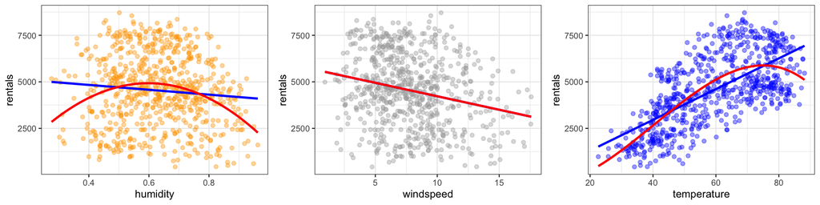

```r
p1 <- ggplot(bikes2, aes(x=humidity, y=rentals)) +
  geom_point(colour="orange", alpha = 0.4) +
  geom_smooth(method = "lm", formula = y ~ x, se = FALSE, color = "blue") +
  geom_smooth(method = "lm", formula = y ~ poly(x, 2), se = FALSE, color = "red")

p2 <- ggplot(bikes2, aes(x=windspeed, y=rentals)) +
  geom_point(colour="darkgrey", alpha = 0.4) +
  geom_smooth(method = "lm", formula = y ~ x, se = FALSE, color = "blue") +
  geom_smooth(method = "lm", formula = y ~ poly(x, 1), se = FALSE, color = "red")

p3 <- ggplot(bikes2, aes(x=temperature, y=rentals)) +
  geom_point(colour="blue", alpha = 0.4) +
  geom_smooth(method = "lm", formula = y ~ x, se = FALSE, color = "blue") +
  geom_smooth(method = "lm", formula = y ~ poly(x, 3), se = FALSE, color = "red")

plot_grid(p1, p2, p3, nrow = 1)
```

```r
bikes_mod3 <- lm(
  data = bikes2,
  rentals ~
    poly(humidity, 2) +
    poly(windspeed, 1) +
    poly(temperature, 3))

summary(bikes_mod3)
```

```
Call:
lm(formula = rentals ~ poly(humidity, 2) + poly(windspeed, 1) +
    poly(temperature, 3), data = bikes2)

Residuals:
     Min       1Q   Median       3Q      Max
-3028.02  -973.19   -66.55   962.25  2864.60

Coefficients:
                       Estimate Std. Error t value Pr(>|t|)
(Intercept)             4535.76      45.08 100.626  < 2e-16 ***
poly(humidity, 2)1    -15982.05    1285.06 -12.437  < 2e-16 ***
poly(humidity, 2)2     -5302.21    1241.15  -4.272 2.21e-05 ***
poly(windspeed, 1)     -9955.12    1267.73  -7.853 1.54e-14 ***
poly(temperature, 3)1  33508.80    1238.04  27.066  < 2e-16 ***
poly(temperature, 3)2 -15626.11    1235.22 -12.650  < 2e-16 ***
poly(temperature, 3)3  -5196.36    1205.09  -4.312 1.85e-05 ***
---
Signif. codes:  0 ‘***’ 0.001 ‘**’ 0.01 ‘*’ 0.05 ‘.’ 0.1 ‘ ’ 1

Residual standard error: 1198 on 699 degrees of freedom
Multiple R-squared:  0.6124,    Adjusted R-squared:  0.6091
F-statistic: 184.1 on 6 and 699 DF,  p-value: < 2.2e-16
```

#### Categorical Variables

```r
options(width = 100)
glimpse(bikes2)
```

```
Rows: 706
Columns: 12
$ date        <date> 2011-01-01, 2011-01-02, 2011-01-03, 2011-01-04, 2011-01-05, 2011-01-06, 2011…
$ season      <dbl> 1, 1, 1, 1, 1, 1, 1, 1, 1, 1, 1, 1, 1, 1, 1, 1, 1, 1, 1, 1, 1, 1, 1, 1, 1, 1,…
$ holiday     <dbl> 0, 0, 0, 0, 0, 0, 0, 0, 0, 0, 0, 0, 0, 0, 0, 0, 1, 0, 0, 0, 0, 0, 0, 0, 0, 0,…
$ weekday     <dbl> 6, 0, 1, 2, 3, 4, 5, 6, 0, 1, 2, 3, 4, 5, 6, 0, 1, 2, 3, 4, 5, 6, 0, 1, 2, 3,…
$ weather     <dbl> 2, 2, 1, 1, 1, 1, 2, 2, 1, 1, 2, 1, 1, 1, 2, 1, 2, 2, 2, 2, 1, 1, 1, 1, 2, 3,…
$ temperature <dbl> 46.71653, 48.35024, 34.21239, 34.52000, 36.80056, 34.88784, 34.22576, 31.5590…
$ realfeel    <dbl> 46.39865, 45.22419, 25.70131, 28.40009, 30.43728, 30.90523, 28.01007, 22.4757…
$ humidity    <dbl> 0.805833, 0.696087, 0.437273, 0.590435, 0.436957, 0.518261, 0.498696, 0.53583…
$ windspeed   <dbl> 6.679665, 10.347140, 10.337565, 6.673420, 7.780994, 3.728766, 7.024377, 11.10…
$ rentals     <dbl> 985, 801, 1349, 1562, 1600, 1606, 1510, 959, 822, 1321, 1263, 1162, 1406, 142…
$ pred1       <dbl> 3500.155, 3628.394, 2518.638, 2542.784, 2721.798, 2571.658, 2519.688, 2310.35…
$ pred2       <dbl> 3095.219, 3139.934, 2836.176, 2808.517, 3335.039, 3401.071, 3029.353, 2233.92…
```

```r
bikes2 <- bikes2 %>%
  mutate(
    season = as.factor(season),
    holiday = as.factor(holiday),
    weekday = as.factor(weekday),
    weather = as.factor(weather)
  )
summary(bikes2[,c("season", "holiday", "weekday", "weather")])
```

```
 season  holiday weekday weather
 1:177   0:685   0:103   1:448
 2:180   1: 21   1:103   2:243
 3:175           2:103   3: 15
 4:174           3:100
                 4:100
                 5:101
                 6: 96
```

Before we start making use of our categorical features in our model, let’s go ahead and revalue them from numbers which are hard to interpret as a human to more readable values.

```r
bikes2 <- bikes2 %>%
  mutate(
    season = recode_factor(season, `1`="Winter", `2`="Spring", `3`="Summer", `4`="Fall"),
    holiday = recode_factor(holiday, `0`="No", `1`="Yes"),
    weekday = recode_factor(weekday,
                            `0`="Sunday",
                            `1`="Monday",
                            `2`="Tuesday",
                            `3`="Wednesday",
                            `4`="Thursday",
                            `5`="Friday",
                            `6`="Saturday"),
    weather = recode_factor(weather, `1`="Clear", `2`="Light precipitation", `3`="Heavy precipitation"))
```

Now let’s start incrementally adding in some of our new categorical features and see how the model performs.

```r
bikes_mod4 <- lm(
  data = bikes2,
  rentals ~
    poly(humidity, 2) +
    poly(windspeed, 1) +
    poly(temperature, 3) +
    season)

summary(bikes_mod4)
```

```
Call:
lm(formula = rentals ~ poly(humidity, 2) + poly(windspeed, 1) +
    poly(temperature, 3) + season, data = bikes2)

Residuals:
    Min      1Q  Median      3Q     Max
-3505.9  -954.6   -71.0  1011.6  3253.1

Coefficients:
                      Estimate Std. Error t value Pr(>|t|)
(Intercept)             4034.8      121.2  33.283  < 2e-16 ***
poly(humidity, 2)1    -16614.8     1244.3 -13.353  < 2e-16 ***
poly(humidity, 2)2     -4827.3     1202.9  -4.013 6.64e-05 ***
poly(windspeed, 1)     -8439.0     1237.1  -6.822 1.95e-11 ***
poly(temperature, 3)1  31242.1     2133.2  14.646  < 2e-16 ***
poly(temperature, 3)2 -12877.0     1416.6  -9.090  < 2e-16 ***
poly(temperature, 3)3  -6293.0     1185.9  -5.307 1.50e-07 ***
seasonSpring             392.8      166.8   2.355  0.01878 *
seasonSummer             583.4      217.1   2.687  0.00738 **
seasonFall              1039.3      143.5   7.244 1.16e-12 ***
---
Signif. codes:  0 ‘***’ 0.001 ‘**’ 0.01 ‘*’ 0.05 ‘.’ 0.1 ‘ ’ 1

Residual standard error: 1152 on 696 degrees of freedom
Multiple R-squared:  0.6427,    Adjusted R-squared:  0.6381
F-statistic: 139.1 on 9 and 696 DF,  p-value: < 2.2e-16
```

Take note of something special that just happened here. We now have coefficients of seasonSpring, seasonSummer and seasonFall. When including categorical variables into a linear regression model, the lm() function automatically creates dummy variables (with values of 0 and 1) for each of the values of the categorical variable. Take note that although there are 4 distinct values for season, seasonWinter was not dummified as it’s considered the baseline, whereby if all other seasons are 0, it’s assumed to be seasonWinter=1 implicitly.

Unlike with the continuous variables, where we interpret the coefficient of a predictor variable as the degree of change in the response variable as a result of a unit change in the value of the predictor (assuming all other predictors are held constant), we interpret the coefficients of the categorical predictors as the average difference in the change of the response variable between each predictor value and the baseline. In other words, in our model, the coefficient for seasonSpring is the average difference in the number of bike rentals between spring and the baseline of winter. Similarly, the coefficients for seasonSummer and seasonFall are the average differences in the number of bike rentals between summer and winter, and between fall and winter, respectively.

#### Variable Interactions

In our bikes2 data, we could expect some sort of interaction effect between the windspeed and weather predictors or between the weather and temperature predictors. It is reasonable to assume that if both the overall weather condition worsened and windspeeds increased, it would have a more significant impact on the number of bike rentals than if either windspeeds alone increased or overall weather conditions alone worsened. R provides us with a way to specify these interaction effects in our model by using the * operator.

```r
bikes_mod5 <- lm(
  data = bikes2,
  rentals ~
    poly(humidity, 2) +
    poly(temperature, 3) +
    season +
    windspeed * weather)

summary(bikes_mod5)
```

```
Call:
lm(formula = rentals ~ poly(humidity, 2) + poly(temperature,
    3) + season + windspeed * weather, data = bikes2)

Residuals:
    Min      1Q  Median      3Q     Max
-3507.7  -982.5   -74.6   988.4  3134.1

Coefficients:
                                      Estimate Std. Error t value Pr(>|t|)
(Intercept)                            4608.74     203.31  22.669  < 2e-16 ***
poly(humidity, 2)1                   -15011.96    1646.78  -9.116  < 2e-16 ***
poly(humidity, 2)2                    -4413.05    1303.01  -3.387 0.000747 ***
poly(temperature, 3)1                 30815.95    2173.45  14.178  < 2e-16 ***
poly(temperature, 3)2                -12857.34    1413.25  -9.098  < 2e-16 ***
poly(temperature, 3)3                 -6049.07    1185.19  -5.104 4.30e-07 ***
seasonSpring                            419.40     167.25   2.508 0.012382 *
seasonSummer                            626.89     217.94   2.876 0.004146 **
seasonFall                             1084.86     143.75   7.547 1.41e-13 ***
windspeed                               -71.98      19.46  -3.700 0.000233 ***
weatherLight precipitation              483.51     259.10   1.866 0.062444 .
weatherHeavy precipitation            -1363.77     973.25  -1.401 0.161584
windspeed:weatherLight precipitation    -70.25      30.69  -2.289 0.022375 *
windspeed:weatherHeavy precipitation     60.12      90.48   0.664 0.506651
---
Signif. codes:  0 ‘***’ 0.001 ‘**’ 0.01 ‘*’ 0.05 ‘.’ 0.1 ‘ ’ 1

Residual standard error: 1147 on 692 degrees of freedom
Multiple R-squared:  0.6479,    Adjusted R-squared:  0.6413
F-statistic: 97.94 on 13 and 692 DF,  p-value: < 2.2e-16
```

We can see from the model output that compared to bikes _mod4, we improve upon both our residual standard error and adjusted R-squared. We also see that some of our new coefficients are significant.

Before we get into the final variable selection phase (we will be using a combination of forward and backward selection known as mixed selection), let’s create some additional candidate predictors first.

```r
bikes2 <- bikes2 %>%
  mutate(
    day = as.numeric(date-min(date)),
    month = as.factor(month(date)),
    year = as.factor(year(date))) %>%
  select(-date)
```

## Predictor Selection Phase

It’s time to proceed with mixed selection now. Now that we have our new candidate predictors, we proceed with the ols_step_both _p() function. The function takes four parameters, and the first is a linear model with all candidate predictors (model). Our candidate predictors include all the independent variables in our bikes2 data as well as the interaction term for windspeed and weather. The second parameter of the function is the p-value threshold for entry into the process (pent), the third is the p-value threshold for removal (prem), and the last is a flag indicating how much detail to print (details). For our example, we set the values for pent, prem, and details as 0.2, 0.01, and FALSE, respectively.

```r
options(width = 100)
stepwiseRegression <- ols_step_both_p(
  model = lm(
    data = bikes2,
    rentals ~
      poly(humidity, 2) +
      poly(temperature, 3) +
      season +
      windspeed * weather +
      weekday +
      holiday +
      #realfeel +
      day +
      month +
      year),
  pent = 0.2,
  prem = 0.01,
  details = FALSE)

stepwiseRegression
```

```
                                       Stepwise Selection Summary
--------------------------------------------------------------------------------------------------------
                                 Added/                   Adj.
Step          Variable          Removed     R-Square    R-Square      C(p)          AIC          RMSE
--------------------------------------------------------------------------------------------------------
   1    poly(temperature, 3)    addition       0.495       0.492    2613.1830    12202.2889    1364.6699
   2            day             addition       0.761       0.760     864.9630    11674.3296     938.2865
   3     poly(humidity, 2)      addition       0.821       0.820     473.5680    11473.9293     812.9946
   4     windspeed:weather      addition       0.844       0.842     325.9290    11383.4534     760.9361
   5           month            addition       0.865       0.861     190.5760    11303.5502     713.6163
   6          weekday           addition       0.872       0.867     148.4740    11279.4437     698.6662
   7          holiday           addition       0.875       0.870     133.1470    11266.7369     691.9366
   8            year            addition       0.877       0.872     118.7200    11254.5050     685.5032
   9            day             removal        0.876       0.871     121.2260    11256.4376     686.9079
  10           season           addition       0.896       0.892      -7.4950    11138.3858     630.5309
  11          weather           addition       0.897       0.892      -9.9210    11137.7781     629.4098
--------------------------------------------------------------------------------------------------------
```

```r
summary(stepwiseRegression$model)
```

```
Call:
lm(formula = paste(response, "~", paste(preds, collapse = " + ")),
    data = l)

Residuals:
     Min       1Q   Median       3Q      Max
-3087.12  -301.84    53.99   374.76  2344.10

Coefficients:
                                      Estimate Std. Error t value Pr(>|t|)
(Intercept)                           3029.893    167.774  18.059  < 2e-16 ***
poly(temperature, 3)1                22405.020   1761.770  12.717  < 2e-16 ***
poly(temperature, 3)2                -9822.808    931.780 -10.542  < 2e-16 ***
poly(temperature, 3)3                -7437.488    760.399  -9.781  < 2e-16 ***
poly(humidity, 2)1                   -8097.715    963.815  -8.402 2.61e-16 ***
poly(humidity, 2)2                   -3752.737    729.385  -5.145 3.51e-07 ***
month2                                  53.241    122.969   0.433 0.665181
month3                                 285.328    144.455   1.975 0.048654 *
month4                                 -37.984    210.832  -0.180 0.857079
month5                                 170.300    224.464   0.759 0.448299
month6                                 157.346    236.708   0.665 0.506454
month7                                 226.650    261.492   0.867 0.386385
month8                                   5.975    253.408   0.024 0.981194
month9                                 173.066    227.390   0.761 0.446865
month10                               -213.878    207.494  -1.031 0.303021
month11                               -528.634    198.711  -2.660 0.007993 **
month12                               -292.918    156.268  -1.874 0.061301 .
weekdayMonday                          166.879     90.758   1.839 0.066397 .
weekdayTuesday                         268.037     88.688   3.022 0.002604 **
weekdayWednesday                       341.950     89.324   3.828 0.000141 ***
weekdayThursday                        376.638     89.262   4.219 2.78e-05 ***
weekdayFriday                          462.675     89.358   5.178 2.97e-07 ***
weekdaySaturday                        454.671     89.714   5.068 5.20e-07 ***
holidayYes                            -488.579    148.152  -3.298 0.001026 **
year2012                              1929.693     49.327  39.121  < 2e-16 ***
seasonSpring                           797.334    149.515   5.333 1.32e-07 ***
seasonSummer                          1115.466    180.985   6.163 1.23e-09 ***
seasonFall                            1687.368    150.751  11.193  < 2e-16 ***
weatherLight precipitation            -159.740    144.179  -1.108 0.268290
weatherHeavy precipitation           -1041.977    543.274  -1.918 0.055539 .
windspeed:weatherClear                 -62.492     10.769  -5.803 1.00e-08 ***
windspeed:weatherLight precipitation   -89.833     13.505  -6.652 6.00e-11 ***
windspeed:weatherHeavy precipitation   -74.036     49.357  -1.500 0.134077
---
Signif. codes:  0 ‘***’ 0.001 ‘**’ 0.01 ‘*’ 0.05 ‘.’ 0.1 ‘ ’ 1

Residual standard error: 629.4 on 673 degrees of freedom
Multiple R-squared:  0.8969,    Adjusted R-squared:  0.892
F-statistic:   183 on 32 and 673 DF,  p-value: < 2.2e-16
```

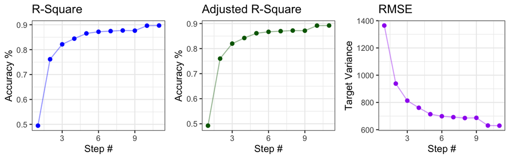

```r
p1 <- ggplot(
  as.data.frame(stepwiseRegression$rsquare),
  aes(x=seq(1, stepwiseRegression$steps, 1), y=stepwiseRegression$rsquare)) +
    geom_path(colour="blue", alpha = 0.4) +
    geom_point(colour="blue") +
    labs(title = "R-Square", x = "Step #", y = "Accuracy %")

p2 <- ggplot(
  as.data.frame(stepwiseRegression$adjr),
  aes(x=seq(1, stepwiseRegression$steps, 1), y=stepwiseRegression$adjr)) +
    geom_path(colour="darkgreen", alpha = 0.4) +
    geom_point(colour="darkgreen") +
    labs(title = "Adjusted R-Square", x = "Step #", y = "Accuracy %")

p3 <- ggplot(
  as.data.frame(stepwiseRegression$rmse),
  aes(x=seq(1, stepwiseRegression$steps, 1), y=stepwiseRegression$rmse)) +
    geom_path(colour="purple", alpha = 0.4) +
    geom_point(colour="purple") +
    labs(title = "RMSE", x = "Step #", y = "Target Variance")

plot_grid(p1, p2, p3, nrow = 1, ncol = 3)
```